# In-Class Assignment 2 - Sample Solution

[Nao Mimoto](https://nmimoto.github.io/)

# 1. This output is made by R markdown (R notebook)

You can execute the R code chunk by clicking the *Run* button on your right or by placing your cursor inside it and pressing *Cmd+Shift+Enter*.

## You can keep your note and Math formula with Latex, for example,

- Central Limt Theorem says, when $X_1, \ldots, X_n$ are i.i.d. random variable from a distribution $F(x)$ with mean $E(X)=\mu$ and variance $V(X)=\sigma^2$, the sample mean is approximately normally distributed:

$$\overline X \sim N\left(\mu, \frac{\sigma^2}{n}\right).$$

### And you can keep the R code, and output at the same time.

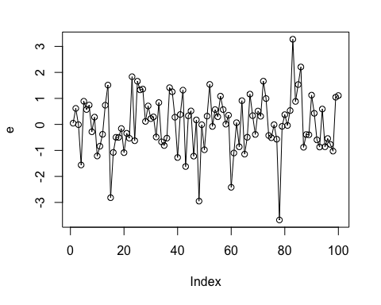

```r
  #- Simulate White Noise (Click "play" bottun on your right in R studio)
  e <- rnorm(100, 0, 1)        # generate 100 N(0,1) error
  plot(e, type="o")
```

# 2. Analysis of Global Temp data

## Load the data from web

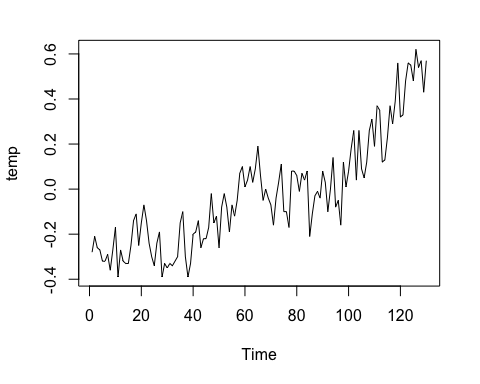

```r
D  <- read.csv("https://nmimoto.github.io/datasets/gtemp.csv")
D1 <- ts(D, start=c(1), freq=1)    # turn D into time series object
D2 <- diff(D1)                        # Take monthly difference
plot(D1)
```

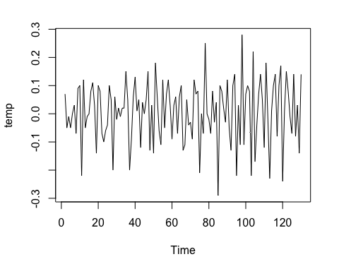

```r
plot(D2)
```

#### 1. Does “D2” look like White Noise, or does it look like AR(p)? Examine plots of ACF and PACF and explain your thoughts briefly.

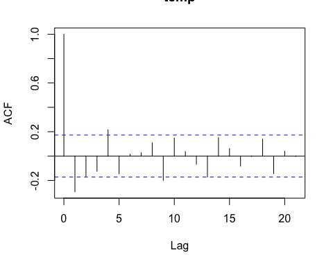

```r
acf(D2)
```

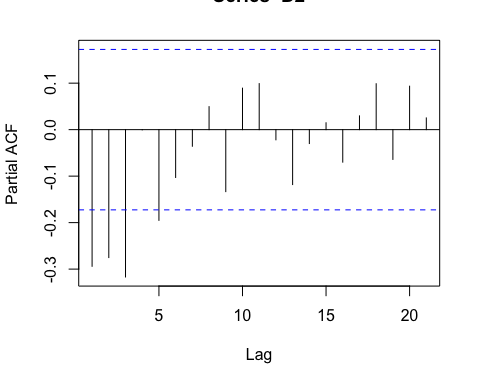

```r
pacf(D2)
```

ACF and PACF does not look like those of WN, especially PACF. If we take the plot of ACF to be going down, and PACF cutting off after lag3, then it is a sign of AR(3).

#### 2. Use auto.arima() function in forecast package to fit AR(p) model using AICc as a best fit criteria (auto.arima() uses AICc as default criteria. AICc is a slightly improved version of AIC). What is the suggested model?

```r
library(forecast)
source('https://nmimoto.github.io/R/TS-00.txt')
auto.arima(D2, d=0, max.q=0)     # Fit AR(p) model
```

```
Series: D2
ARIMA(3,0,0) with non-zero mean

Coefficients:
          ar1      ar2      ar3    mean
      -0.4610  -0.3897  -0.3143  0.0063
s.e.   0.0836   0.0861   0.0833  0.0039

sigma^2 estimated as 0.009342:  log likelihood=120.14
AIC=-230.27   AICc=-229.78   BIC=-215.97
```

AR(3) with mean is suggested. However, the mean is not significant, and should be removed.

#### 3. From AR(p) model suggested in part 2, investigate AR(p-1) and AR(p+1). Remove any parameters that has non-significant parameter estimate. What is your final AR model?

```r
Arima(D2, order=c(2,0,0))
```

```
Series: D2
ARIMA(2,0,0) with non-zero mean

Coefficients:
          ar1      ar2    mean
      -0.3742  -0.2742  0.0062
s.e.   0.0848   0.0849  0.0054

sigma^2 estimated as 0.01031:  log likelihood=113.42
AIC=-218.84   AICc=-218.52   BIC=-207.4
```

```r
Arima(D2, order=c(4,0,0))
```

```
Series: D2
ARIMA(4,0,0) with non-zero mean

Coefficients:
          ar1      ar2      ar3     ar4    mean
      -0.4596  -0.3880  -0.3124  0.0043  0.0063
s.e.   0.0880   0.0932   0.0925  0.0882  0.0039

sigma^2 estimated as 0.009417:  log likelihood=120.14
AIC=-228.27   AICc=-227.58   BIC=-211.11
```

```r
Arima(D2, order=c(2,0,0), include.mean=FALSE)
```

```
Series: D2
ARIMA(2,0,0) with zero mean

Coefficients:
          ar1      ar2
      -0.3678  -0.2667
s.e.   0.0850   0.0851

sigma^2 estimated as 0.01033:  log likelihood=112.76
AIC=-219.51   AICc=-219.32   BIC=-210.93
```

```r
Arima(D2, order=c(4,0,0), include.mean=FALSE)
```

```
Series: D2
ARIMA(4,0,0) with zero mean

Coefficients:
          ar1      ar2      ar3     ar4
      -0.4413  -0.3652  -0.2898  0.0251
s.e.   0.0881   0.0929   0.0923  0.0880

sigma^2 estimated as 0.009522:  log likelihood=118.92
AIC=-227.84   AICc=-227.35   BIC=-213.54
```

```r
Arima(D2, order=c(3,0,0), include.mean=FALSE)
```

```
Series: D2
ARIMA(3,0,0) with zero mean

Coefficients:
          ar1      ar2      ar3
      -0.4488  -0.3750  -0.3009
s.e.   0.0840   0.0864   0.0837

sigma^2 estimated as 0.009453:  log likelihood=118.88
AIC=-229.76   AICc=-229.44   BIC=-218.32
```

In all AR(2), AR(3), and AR(4) model mean is not significant whenever it is included.

Without the mean, AR(4) has non-significant $\phi_4$. Therefore, AR(3) without mean is the best model.

#### 4. In your final AR model, what is the estimate for the standard deviation of the error term? What is the estimate of unconditional standard deviation?

```r
Fit01 <- Arima(D2, order=c(3,0,0), include.mean=FALSE)
Fit01
```

```
Series: D2
ARIMA(3,0,0) with zero mean

Coefficients:
          ar1      ar2      ar3
      -0.4488  -0.3750  -0.3009
s.e.   0.0840   0.0864   0.0837

sigma^2 estimated as 0.009453:  log likelihood=118.88
AIC=-229.76   AICc=-229.44   BIC=-218.32
```

```r
sqrt(Fit01$sigma2)
```

```
[1] 0.09722473
```

```r
sd(D2)
```

```
[1] 0.1097048
```

Estimate of the conditional standard deviation $\sigma$ is 0.097224, and unconditonal standard deviation $SD(Y_t)$ is estimated as 0.1097.

#### 5. Perform the residual analysis using Randomness.tests() provided on the class web site. Is model fit adequate? Comment on the quality of your residuals.

```
  B-L test H0: the sereis is uncorrelated
  M-L test H0: the square of the sereis is uncorrelated
  J-B test H0: the sereis came from Normal distribution
  SD         : Standard Deviation of the series

      BL15  BL20  BL25  ML15  ML20    JB    SD
[1,] 0.314 0.359 0.538 0.528 0.404 0.395 0.096
```

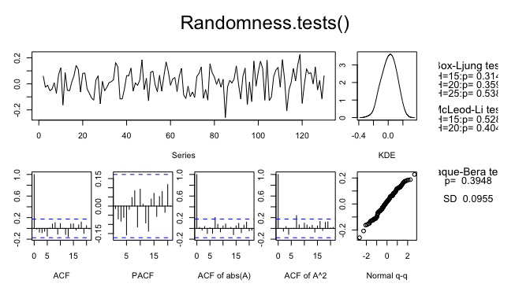

```r
source("https://nmimoto.github.io/R/TS-00.txt")
Randomness.tests(Fit01$residuals)
```

P-values are high in all 3 Ljung-Box tests and 2 McLeod-Li test, indicating that the residuals are uncorrelated. Therefore the model is fitting adequately.

P-value is high for J-B test, indicating that the residuals looks normally distributed.

#### 6. There are 129 observations in D2. Perform 1-month rolling forecast of the data with model found in part 3. Use window size of 100, and predict the last 29 observation 1-month at a time in retrospective. What is the prediction root mean square? Is the prediction satisfactory? Is the prediction rMSE (from the last 29 out-of-sample comparison) close to what it was suggested by your model (this is what #7 is asking)?

```r
#---------------------------------------
#--- Rolling 1-period forecast with AR(4)
  Y <- D2                 # Entire data
  window.size <- 100       # Window size for estimation
  order.in <- c(3,0,0)     # model order
    Yhat  <- Yhat.CIu <- Yhat.CIl <- 0        # initialize what needs to be saved
    for (i in 1:(length(Y)-window.size)) {
      # Force to fit AR(2) each time on last 100 obs.
      Fit00 <- Arima( Y[i:(i+window.size-1)], order=order.in, include.mean=FALSE)     # <--- no mean

      Y.h  <- predict(Fit00, n.ahead=1)       # one step prediction
      Yhat[i]     <- Y.h$pred
      Yhat.CIu[i] <- Yhat[i]+1.96*Y.h$se
      Yhat.CIl[i] <- Yhat[i]-1.96*Y.h$se
    }
  # Yhat starts at window.size+1 up to length(Y)
  Yhat     = ts(Yhat, start=time(Y)[window.size+1], freq=1)
  Yhat.CIu = ts(Yhat, start=time(Y)[window.size+1], freq=1)
  Yhat.CIl = ts(Yhat, start=time(Y)[window.size+1], freq=1)
  Y1 = window(Y, start=time(Y)[1], end=time(Y)[window.size])
  #- Calculate prediction performance
  Pred.error = Y[(window.size+1):length(Y)] - Yhat
  Pred.rMSE =  sqrt(  mean( (Pred.error)^2 ) )     # prediction root Mean Squared Error
  c( mean(Pred.error), Pred.rMSE )                 # Av Pred Error, and pred rMSE
```

```
[1] 0.03046302 0.11734950
```

```r
  #- Plot the prediction result with original data
  plot(Y, type="o", col="red",
    main="Rolling 1-step prediction (Red=Actual, Blue=Prediction)" )
  lines( Y1,       type="o")
```

```r
  lines( Yhat,     type="o", col="blue")
  lines( Yhat.CIu, type="l", col="gray30", lty=2)
```

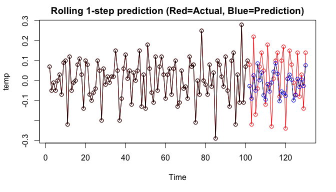

```r
  lines( Yhat.CIl, type="l", col="gray30", lty=2)
  # - Plot the prediction error
  layout(matrix(1:2, 1, 2))    # two plots side by side
```

```r
  plot( (window.size+1):length(Y), Pred.error, type="o", main="Prediction Error (Red-Blue)" )
  abline(h=c(-1.96, 1.96), col="blue", lty=2)
```

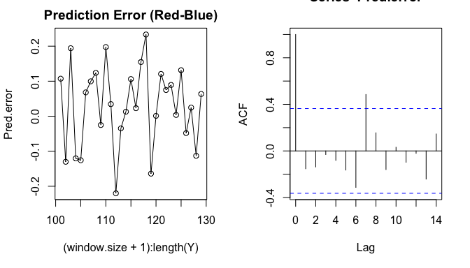

```r
  acf(Pred.error)
  layout(1)                    # reset the layout
```

When rolling 1-step prediction is performed on the last 29 observations using a window size of 100 observations, prediction rMSE came out to be .11734. This is higher than $\hat \sigma=$.097224, which is what the prediction rMSE should be if the data actually came from AR(3) model.

Prediction rMSE of .11734 is actually higher than unconditional SD of 0.1097. The model is not offerting anything better than the prediction using unconditional SD. This does not mean that the model is wrong or not fitting, since residual check went well. Rather, the model has such a high $\sigma$ compared to the unconditional SD, it is not useful in forecasting.

#### 7. If you perform 1-month prediction on the future observation (obs 130). What is the estimate of the theoretical prediction rMSE? What is the 95% CI for 1-month prediction for the next monthly difference (obs 130)?

```r
time(D2)
```

```
Time Series:
Start = 2
End = 130
Frequency = 1
  [1]   2   3   4   5   6   7   8   9  10  11  12  13  14  15  16  17  18  19  20  21  22  23  24  25  26  27  28  29  30  31  32  33
 [33]  34  35  36  37  38  39  40  41  42  43  44  45  46  47  48  49  50  51  52  53  54  55  56  57  58  59  60  61  62  63  64  65
 [65]  66  67  68  69  70  71  72  73  74  75  76  77  78  79  80  81  82  83  84  85  86  87  88  89  90  91  92  93  94  95  96  97
 [97]  98  99 100 101 102 103 104 105 106 107 108 109 110 111 112 113 114 115 116 117 118 119 120 121 122 123 124 125 126 127 128 129
[129] 130
```

```r
#--- 10-period forecast
forecast(Fit01)
```

```
    Point Forecast      Lo 80     Hi 80      Lo 95     Hi 95
131  -0.0193645593 -0.1439631 0.1052340 -0.2099215 0.1711924
132  -0.0016804318 -0.1382530 0.1348921 -0.2105501 0.2071892
133  -0.0341096228 -0.1723833 0.1041640 -0.2455809 0.1773616
134   0.0217657768 -0.1166758 0.1602073 -0.1899623 0.2334939
135   0.0035270689 -0.1377165 0.1447706 -0.2124863 0.2195404
136   0.0005187047 -0.1407682 0.1418056 -0.2155610 0.2165984
137  -0.0081045490 -0.1495586 0.1333495 -0.2244399 0.2082308
138   0.0023816876 -0.1391296 0.1438930 -0.2140412 0.2188046
139   0.0018139950 -0.1398018 0.1434297 -0.2147686 0.2183966
140   0.0007313771 -0.1408889 0.1423517 -0.2158582 0.2173210
```

The forecast for the nest observation is -0.019364. 95% confidence interval is (-0.2099215 0.1711924).

(129 observations in D2 was labeled 2…. 130, so the 130th observation forecasted has label 131.)

#### 8. Using all 129 observations, perform 12-month forecast. Plot the graph. What is the line that h-step forecast is approaching?

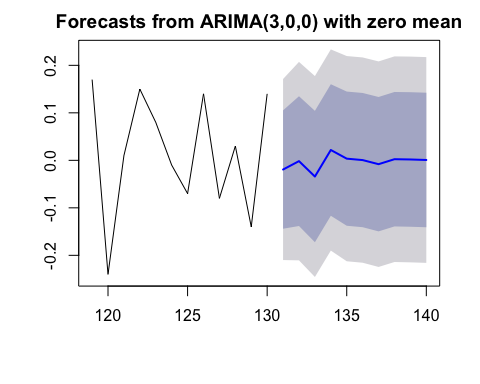

```r
#--- 12-period forecast
plot( forecast(Fit01), 12)
```

The h-step forecast of AR(3) approaches 0, since the mode does not include mean term.

If the model has a mean term, then h-step forecast will approach the mean.

#### 9. Write down mathematical formula for your final AR model. Don’t forget parameters for your error term.

```r
Fit01
```

```
Series: D2
ARIMA(3,0,0) with zero mean

Coefficients:
          ar1      ar2      ar3
      -0.4488  -0.3750  -0.3009
s.e.   0.0840   0.0864   0.0837

sigma^2 estimated as 0.009453:  log likelihood=118.88
AIC=-229.76   AICc=-229.44   BIC=-218.32
```

My model is AR(3) without mean. So denoting the observation with $Y_t$,

$$Y_t = X_t$$
and $X_t$ is AR(3) without mean.

$$X_t = \phi_1 X_{t-1} + \phi_2 X_{t-2} + \phi_3 X_{t-3} + e_t$$
where $e_t \sim WN(0, \sigma^2)$.

Using the estimates from # 3,
$$X_t = (-0.4488) X_{t-1} + (-0.3750) X_{t-2} + (-0.3009) X_{t-3} + e_t$$
where $e_t \sim WN(0, (.097224)^2)$.